# report

```python
# в dataset лежат 3 файла, статусы и 2 файла - метрики (аттрибуты) от поставщика
# нужно для каждого статуса в отдельности провести анализ данных на предмет поиска взимосвязей и влияний метрик от поставщиа н наши статусы
```

```python
import pandas as pd                      # подключаем библиотеку pandas для работы с таблицами
import numpy as np                       # подключаем библиотеку numpy
from matplotlib import pyplot as plt     # подключаем библиотеку pyplot для построения графиков
import seaborn as sns
import warnings
warnings.filterwarnings('ignore')
plt.style.use('seaborn-darkgrid')
palette = plt.get_cmap('Set2')
```

```python
attr_df = pd.read_csv('dataset/df_equifax_09022022.csv', sep=',', index_col=0)
attr_df = attr_df.drop(columns=['dateofreport'])
```

```python
attr_df.info()
```

```
<class 'pandas.core.frame.DataFrame'>
Int64Index: 29125 entries, 0 to 29124
Columns: 104 entries, app_id to attr_id_list_104
dtypes: float64(103), int64(1)
memory usage: 23.3 MB
```

```python
attr_df.head()
```

|  | app_id | attr_id_list_2627 | attr_id_list_2637 | attr_id_list_2647 | attr_id_list_2657 | attr_id_list_2667 | attr_id_list_2677 | attr_id_list_2687 | attr_id_list_2697 | attr_id_list_2707 | ... | attr_id_list_3547 | attr_id_list_3557 | attr_id_list_3567 | attr_id_list_3577 | attr_id_list_3587 | attr_id_list_1437 | attr_id_list_114 | attr_id_list_53 | attr_id_list_322 | attr_id_list_104 |
| --- | --- | --- | --- | --- | --- | --- | --- | --- | --- | --- | --- | --- | --- | --- | --- | --- | --- | --- | --- | --- | --- |
| 0 | 1 | 1.0 | 0.0 | 0.0 | 0.0 | 0.0 | 0.0 | 1.0 | 1.0 | 1.0 | ... | NaN | NaN | NaN | 0.0 | 0.0 | NaN | 0.0 | NaN | 0.000 | 0.000 |
| 1 | 4 | 11.0 | 0.0 | 0.0 | 0.0 | 0.0 | 0.0 | 0.0 | 1.0 | 1.0 | ... | NaN | NaN | NaN | NaN | NaN | 4725134.27 | 9.0 | 0.692 | NaN | NaN |
| 2 | 6 | 49.0 | 5.0 | 8.0 | 14.0 | 16.0 | 20.0 | 25.0 | 37.0 | 45.0 | ... | 120.0 | 123.0 | 123.0 | 26.0 | 0.0 | 1471233.00 | 104.0 | 0.952 | NaN | 1.134 |
| 3 | 7 | 57.0 | 3.0 | 8.0 | 11.0 | 26.0 | 37.0 | 42.0 | 47.0 | 47.0 | ... | 97.0 | 97.0 | 97.0 | 6.0 | 0.0 | 455687.70 | 71.0 | 0.986 | NaN | NaN |
| 4 | 8 | 74.0 | 0.0 | 1.0 | 9.0 | 11.0 | 13.0 | 16.0 | 21.0 | 27.0 | ... | 92.0 | 128.0 | 202.0 | 77.0 | 0.0 | 1658282.50 | 109.0 | 0.771 | 0.651 | 1.000 |

5 rows × 104 columns

```python
score_df = pd.read_csv('dataset/scored_data1.csv',sep=';')
score_df = score_df.drop(columns=['dateofreport','hit'])
```

```python
score_df.info()
```

```
<class 'pandas.core.frame.DataFrame'>
RangeIndex: 26056 entries, 0 to 26055
Data columns (total 2 columns):
 #   Column  Non-Null Count  Dtype
---  ------  --------------  -----
 0   NUM     26056 non-null  int64
 1   score   26056 non-null  int64
dtypes: int64(2)
memory usage: 407.2 KB
```

```python
score_df
```

|  | NUM | score |
| --- | --- | --- |
| 0 | 1 | 0 |
| 1 | 4 | 581 |
| 2 | 6 | 621 |
| 3 | 7 | 500 |
| 4 | 8 | 627 |
| ... | ... | ... |
| 26051 | 26309 | 476 |
| 26052 | 26314 | 494 |
| 26053 | 26317 | 482 |
| 26054 | 26318 | 543 |
| 26055 | 26320 | 513 |

26056 rows × 2 columns

```python
special_df = pd.read_csv('dataset/special_df_num1_numonline_1cnt_None.csv', sep=';')
```

```python
special_df.info()
```

```
<class 'pandas.core.frame.DataFrame'>
RangeIndex: 2901 entries, 0 to 2900
Data columns (total 5 columns):
 #   Column     Non-Null Count  Dtype
---  ------     --------------  -----
 0   app_id     2901 non-null   int64
 1   status_3   2901 non-null   float64
 2   status_20  2788 non-null   float64
 3   status_30  2752 non-null   float64
 4   status_60  2114 non-null   float64
dtypes: float64(4), int64(1)
memory usage: 113.4 KB
```

```python
score_df.rename(columns={'NUM': 'app_id'}, inplace=True)
```

```python
scored_attr_df = pd.merge(attr_df,\
                     score_df,\
                     on=['app_id'])
scored_attr_df
```

|  | app_id | attr_id_list_2627 | attr_id_list_2637 | attr_id_list_2647 | attr_id_list_2657 | attr_id_list_2667 | attr_id_list_2677 | attr_id_list_2687 | attr_id_list_2697 | attr_id_list_2707 | ... | attr_id_list_3557 | attr_id_list_3567 | attr_id_list_3577 | attr_id_list_3587 | attr_id_list_1437 | attr_id_list_114 | attr_id_list_53 | attr_id_list_322 | attr_id_list_104 | score |
| --- | --- | --- | --- | --- | --- | --- | --- | --- | --- | --- | --- | --- | --- | --- | --- | --- | --- | --- | --- | --- | --- |
| 0 | 1 | 1.0 | 0.0 | 0.0 | 0.0 | 0.0 | 0.0 | 1.0 | 1.0 | 1.0 | ... | NaN | NaN | 0.0 | 0.0 | NaN | 0.0 | NaN | 0.000 | 0.000 | 0 |
| 1 | 4 | 11.0 | 0.0 | 0.0 | 0.0 | 0.0 | 0.0 | 0.0 | 1.0 | 1.0 | ... | NaN | NaN | NaN | NaN | 4725134.27 | 9.0 | 0.692 | NaN | NaN | 581 |
| 2 | 6 | 49.0 | 5.0 | 8.0 | 14.0 | 16.0 | 20.0 | 25.0 | 37.0 | 45.0 | ... | 123.0 | 123.0 | 26.0 | 0.0 | 1471233.00 | 104.0 | 0.952 | NaN | 1.134 | 621 |
| 3 | 7 | 57.0 | 3.0 | 8.0 | 11.0 | 26.0 | 37.0 | 42.0 | 47.0 | 47.0 | ... | 97.0 | 97.0 | 6.0 | 0.0 | 455687.70 | 71.0 | 0.986 | NaN | NaN | 500 |
| 4 | 8 | 74.0 | 0.0 | 1.0 | 9.0 | 11.0 | 13.0 | 16.0 | 21.0 | 27.0 | ... | 128.0 | 202.0 | 77.0 | 0.0 | 1658282.50 | 109.0 | 0.771 | 0.651 | 1.000 | 627 |
| ... | ... | ... | ... | ... | ... | ... | ... | ... | ... | ... | ... | ... | ... | ... | ... | ... | ... | ... | ... | ... | ... |
| 26051 | 26309 | 41.0 | 4.0 | 6.0 | 13.0 | 19.0 | 28.0 | 30.0 | 30.0 | 39.0 | ... | 28.0 | 28.0 | 10.0 | 0.0 | 256416.66 | 17.0 | 0.994 | NaN | NaN | 476 |
| 26052 | 26314 | 59.0 | 4.0 | 9.0 | 13.0 | 25.0 | 28.0 | 29.0 | 39.0 | 58.0 | ... | 54.0 | 54.0 | 8.0 | 0.0 | 112000.00 | 26.0 | 0.775 | 0.430 | 0.816 | 494 |
| 26053 | 26317 | 59.0 | 0.0 | 2.0 | 8.0 | 10.0 | 15.0 | 22.0 | 30.0 | 35.0 | ... | 72.0 | 72.0 | 22.0 | 2.0 | 275057.51 | 30.0 | 0.754 | 0.705 | 0.701 | 482 |
| 26054 | 26318 | 34.0 | 1.0 | 3.0 | 4.0 | 9.0 | 11.0 | 15.0 | 22.0 | 29.0 | ... | 122.0 | 122.0 | 24.0 | 0.0 | 264072.32 | 66.0 | 0.897 | NaN | NaN | 543 |
| 26055 | 26320 | 46.0 | 2.0 | 4.0 | 4.0 | 15.0 | 19.0 | 22.0 | 35.0 | 46.0 | ... | 86.0 | 86.0 | 6.0 | 0.0 | 455098.00 | 60.0 | 0.912 | NaN | 1.001 | 513 |

26056 rows × 105 columns

```python
special_scored_attr_df = pd.merge(special_df,\
                                scored_attr_df,\
                                on='app_id')
```

```python
special_scored_attr_df
```

|  | app_id | status_3 | status_20 | status_30 | status_60 | attr_id_list_2627 | attr_id_list_2637 | attr_id_list_2647 | attr_id_list_2657 | attr_id_list_2667 | ... | attr_id_list_3557 | attr_id_list_3567 | attr_id_list_3577 | attr_id_list_3587 | attr_id_list_1437 | attr_id_list_114 | attr_id_list_53 | attr_id_list_322 | attr_id_list_104 | score |
| --- | --- | --- | --- | --- | --- | --- | --- | --- | --- | --- | --- | --- | --- | --- | --- | --- | --- | --- | --- | --- | --- |
| 0 | 20 | 0.0 | 0.0 | 0.0 | 0.0 | 57.0 | 3.0 | 5.0 | 15.0 | 27.0 | ... | 6.0 | 9.0 | 89.0 | 0.0 | 42644.00 | 13.0 | 0.842 | 0.746 | NaN | 469 |
| 1 | 34 | 0.0 | 0.0 | 0.0 | 0.0 | 46.0 | 4.0 | 6.0 | 12.0 | 20.0 | ... | 190.0 | 190.0 | 10.0 | 0.0 | 1328127.00 | 144.0 | 0.921 | NaN | 0.977 | 579 |
| 2 | 102 | 1.0 | 1.0 | 1.0 | 1.0 | 50.0 | 1.0 | 6.0 | 8.0 | 25.0 | ... | 321.0 | 321.0 | 8.0 | 0.0 | 5088729.66 | 296.0 | 0.965 | NaN | 1.009 | 559 |
| 3 | 106 | 0.0 | 0.0 | 0.0 | 0.0 | 72.0 | 2.0 | 8.0 | 13.0 | 33.0 | ... | 48.0 | 48.0 | 1.0 | 0.0 | 485142.46 | 29.0 | 0.897 | 0.908 | 0.972 | 597 |
| 4 | 104 | 0.0 | 0.0 | 0.0 | 0.0 | 33.0 | 0.0 | 0.0 | 2.0 | 6.0 | ... | 20.0 | 20.0 | 20.0 | 3.0 | 60753.60 | 15.0 | 0.796 | 0.000 | NaN | 455 |
| ... | ... | ... | ... | ... | ... | ... | ... | ... | ... | ... | ... | ... | ... | ... | ... | ... | ... | ... | ... | ... | ... |
| 2743 | 26223 | 1.0 | 1.0 | NaN | NaN | 46.0 | 0.0 | 3.0 | 4.0 | 20.0 | ... | 18.0 | 18.0 | 34.0 | 0.0 | 48631.00 | 11.0 | 0.874 | NaN | NaN | 469 |
| 2744 | 26158 | 1.0 | 1.0 | NaN | NaN | 50.0 | 5.0 | 9.0 | 13.0 | 15.0 | ... | 4.0 | 7.0 | 68.0 | 0.0 | 20140.00 | 5.0 | 1.000 | NaN | 1.000 | 501 |
| 2745 | 26243 | 1.0 | 1.0 | NaN | NaN | 50.0 | 3.0 | 4.0 | 15.0 | 34.0 | ... | 78.0 | 78.0 | 1.0 | 0.0 | 319328.33 | 61.0 | 0.908 | 0.844 | NaN | 537 |
| 2746 | 26245 | 0.0 | 0.0 | NaN | NaN | 53.0 | 0.0 | 0.0 | 0.0 | 1.0 | ... | 0.0 | 4.0 | 57.0 | 55.0 | 4000.00 | 3.0 | 1.000 | 1.000 | NaN | 488 |
| 2747 | 24521 | 1.0 | 0.0 | NaN | NaN | 52.0 | 3.0 | 8.0 | 13.0 | 24.0 | ... | 191.0 | 191.0 | 24.0 | 0.0 | 2195773.00 | 157.0 | 0.996 | NaN | 1.000 | 652 |

2748 rows × 109 columns

```python
# длина датафрейма
len_of_df = len(special_scored_attr_df)

# список всех статусов
statuses = list(special_df.drop(columns=['app_id']))

# список атрибутов, которые будем удалять
attr_to_drop = []

# если количество пропусков составляет больше 5%, то удаляем атрибут
for i in special_scored_attr_df.drop(columns=statuses):
    if special_scored_attr_df.isna().sum()[i]/len_of_df > 0.05:
        attr_to_drop.append(i)

special_scored_attr_df.drop(columns=attr_to_drop, inplace=True)
```

## Ниже задаём желаемый статус

```python
current_status = 'status_3'
```

```python
status_to_remove = []
for i in special_scored_attr_df.columns:
    if ('status_' in i) & (i!=current_status):
        status_to_remove.append(i)

print('Удаляем следующие статусы:')
print(status_to_remove)
```

```
Удаляем следующие статусы:
['status_20', 'status_30', 'status_60']
```

```python
# удаляем лишние статусы
main_df = special_scored_attr_df.drop(columns=status_to_remove)
```

```python
main_df
```

|  | app_id | status_3 | attr_id_list_2627 | attr_id_list_2637 | attr_id_list_2647 | attr_id_list_2657 | attr_id_list_2667 | attr_id_list_2677 | attr_id_list_2687 | attr_id_list_2697 | ... | attr_id_list_3537 | attr_id_list_3547 | attr_id_list_3557 | attr_id_list_3567 | attr_id_list_3577 | attr_id_list_3587 | attr_id_list_1437 | attr_id_list_114 | attr_id_list_53 | score |
| --- | --- | --- | --- | --- | --- | --- | --- | --- | --- | --- | --- | --- | --- | --- | --- | --- | --- | --- | --- | --- | --- |
| 0 | 20 | 0.0 | 57.0 | 3.0 | 5.0 | 15.0 | 27.0 | 31.0 | 32.0 | 35.0 | ... | 4.0 | 6.0 | 6.0 | 9.0 | 89.0 | 0.0 | 42644.00 | 13.0 | 0.842 | 469 |
| 1 | 34 | 0.0 | 46.0 | 4.0 | 6.0 | 12.0 | 20.0 | 22.0 | 24.0 | 32.0 | ... | 190.0 | 190.0 | 190.0 | 190.0 | 10.0 | 0.0 | 1328127.00 | 144.0 | 0.921 | 579 |
| 2 | 102 | 1.0 | 50.0 | 1.0 | 6.0 | 8.0 | 25.0 | 30.0 | 33.0 | 39.0 | ... | 321.0 | 321.0 | 321.0 | 321.0 | 8.0 | 0.0 | 5088729.66 | 296.0 | 0.965 | 559 |
| 3 | 106 | 0.0 | 72.0 | 2.0 | 8.0 | 13.0 | 33.0 | 40.0 | 47.0 | 63.0 | ... | 48.0 | 48.0 | 48.0 | 48.0 | 1.0 | 0.0 | 485142.46 | 29.0 | 0.897 | 597 |
| 4 | 104 | 0.0 | 33.0 | 0.0 | 0.0 | 2.0 | 6.0 | 6.0 | 10.0 | 23.0 | ... | 19.0 | 20.0 | 20.0 | 20.0 | 20.0 | 3.0 | 60753.60 | 15.0 | 0.796 | 455 |
| ... | ... | ... | ... | ... | ... | ... | ... | ... | ... | ... | ... | ... | ... | ... | ... | ... | ... | ... | ... | ... | ... |
| 2743 | 26223 | 1.0 | 46.0 | 0.0 | 3.0 | 4.0 | 20.0 | 21.0 | 21.0 | 22.0 | ... | 2.0 | 11.0 | 18.0 | 18.0 | 34.0 | 0.0 | 48631.00 | 11.0 | 0.874 | 469 |
| 2744 | 26158 | 1.0 | 50.0 | 5.0 | 9.0 | 13.0 | 15.0 | 15.0 | 23.0 | 23.0 | ... | 4.0 | 4.0 | 4.0 | 7.0 | 68.0 | 0.0 | 20140.00 | 5.0 | 1.000 | 501 |
| 2745 | 26243 | 1.0 | 50.0 | 3.0 | 4.0 | 15.0 | 34.0 | 42.0 | 43.0 | 43.0 | ... | 78.0 | 78.0 | 78.0 | 78.0 | 1.0 | 0.0 | 319328.33 | 61.0 | 0.908 | 537 |
| 2746 | 26245 | 0.0 | 53.0 | 0.0 | 0.0 | 0.0 | 1.0 | 21.0 | 22.0 | 26.0 | ... | 0.0 | 0.0 | 0.0 | 4.0 | 57.0 | 55.0 | 4000.00 | 3.0 | 1.000 | 488 |
| 2747 | 24521 | 1.0 | 52.0 | 3.0 | 8.0 | 13.0 | 24.0 | 26.0 | 30.0 | 32.0 | ... | 129.0 | 187.0 | 191.0 | 191.0 | 24.0 | 0.0 | 2195773.00 | 157.0 | 0.996 | 652 |

2748 rows × 82 columns

```python
# удаляем app_id, так как для анализа он нам не понадобится
main_df.drop(columns='app_id', inplace=True)
```

```python
zero_dispersion = []

# находим константные атрибуты
for i in main_df.drop(columns=current_status):
    if main_df.isna().sum()[i]/len_of_df > 0:
        if main_df[i].var()==0:
            zero_dispersion.append(i)

# удаляем константные атрибуты
main_df.drop(columns=zero_dispersion, inplace=True)
```

```python
# создаём массив для названий категориальных атрибутов
cat_attr = []

# создаём массив для названий числовых атрибутов
num_attr = []

# обрабатываем пропущенные значения
for i in main_df.drop(columns=current_status):
    unique_values = main_df[i].unique()

    # находим и заполняем неуказанные категориальные атрибуты значениями -1
    if (main_df[i].max()-main_df[i].min())==(len(unique_values)-2):
        main_df[i].fillna(main_df[i].min()-1, inplace=True)
        cat_attr.append(main_df[i].name)

    # находим и заполняем потерянные категориальные атрибуты,
    # т.е. те, у которых значения последовательны и видно, что не хватает категории
    elif ((main_df[i].max()-main_df[i].min())==(len(unique_values)-1)):
        for j in range(int(main_df[i].min()), int(main_df[i].max()+1)):
            if j not in unique_values:
                main_df[i].fillna(j, inplace=True)
                cat_attr.append(main_df[i].name)

    # для всех остальных, считаем, что они числовые, а значит отсутствие значения - отсутствие признака
    else:
        main_df[i].fillna(0, inplace=True)
        num_attr.append(main_df[i].name)

for i in main_df.drop(columns=current_status):
    unique_values = main_df[i].unique()
```

```python
# удаляем статусы NaN
main_df.dropna(inplace=True)
```

# Корреляционный анализ

```python
# ограничиваем количество выводимых столбцов до 22
#pd.options.display.max_columns = 22

# создаём общую таблицу корреляции
main_corr_matrix = main_df.corr()

coef_for_status = 0.05
coef_for_multicorr = 0.5

# создаём таблицу корреляции, где корреляция со статусом больше coef_for_status
corr_matrix = main_corr_matrix[abs(main_corr_matrix[current_status])>=coef_for_status]\
[list(main_corr_matrix[abs(main_corr_matrix[current_status])>=coef_for_status].index)]

# отбираем названия атрибутов, отсортированные по убыванию значений корреляции со статусом
attr_by_corr_status = corr_matrix.sort_values(current_status, ascending=False).index[1:]

# создаём таблицу кореляции, где и индекс, и колонки отсортированы по убыванию значений корреляции со статусом.
current_corr_matrix = corr_matrix.sort_values(current_status,ascending=False)[attr_by_corr_status][1:]

flag = True

# ходим по таблице и удаляем один из коррелирующих атрибутов до тех пор,
# пока корреляция между всеми атрибутами не будет меньше coef_for_multicorr
while flag:
    flag2 = False
    flag3 = False
    for i in current_corr_matrix.columns:
        for j in current_corr_matrix.columns:
            if (abs(current_corr_matrix[i][j])>=coef_for_multicorr) & (i!=j):
                print('Сравниваем '+i+'='\
                      +str(corr_matrix[current_status][i])+' и '\
                      +j+'='+str(corr_matrix[current_status][j]))

                if corr_matrix[current_status][i] < corr_matrix[current_status][j]:
                    print('Удаляем '+i+'='+str(corr_matrix[current_status][i]))
                    current_corr_matrix.drop(i, axis=1, inplace=True)
                    current_corr_matrix.drop(i, axis=0, inplace=True)
                    flag2=True
                else:
                    print('Удаляем '+j+'='+str(corr_matrix[current_status][j]))
                    current_corr_matrix.drop(j, axis=1, inplace=True)
                    current_corr_matrix.drop(j, axis=0, inplace=True)
                    flag2=True
                print()
            if flag2:
                break
        if flag2:
                break

    # ещё раз проходим по матрице для поиска атрибутов, корреляция которых больше coef_for_multicorr
    for i in current_corr_matrix.columns:
        for j in current_corr_matrix.columns:
            if (abs(current_corr_matrix[i][j])>=coef_for_multicorr) & (i!=j):
                flag3=True
            if flag3:
                break
        if flag3:
            break
    if flag3:
        continue

    flag = False

current_corr_matrix
```

```
Сравниваем attr_id_list_3427=0.13817910973500813 и attr_id_list_3437=0.1144190138489573
Удаляем attr_id_list_3437=0.1144190138489573

Сравниваем attr_id_list_3507=-0.07883174718943689 и attr_id_list_3517=-0.07994596438571869
Удаляем attr_id_list_3517=-0.07994596438571869

Сравниваем attr_id_list_3507=-0.07883174718943689 и attr_id_list_3527=-0.09082842373718442
Удаляем attr_id_list_3527=-0.09082842373718442

Сравниваем attr_id_list_3507=-0.07883174718943689 и attr_id_list_3497=-0.09578212558764466
Удаляем attr_id_list_3497=-0.09578212558764466

Сравниваем attr_id_list_3507=-0.07883174718943689 и attr_id_list_3537=-0.10555284880323147
Удаляем attr_id_list_3537=-0.10555284880323147

Сравниваем attr_id_list_3547=-0.11246439934050861 и attr_id_list_3567=-0.11519563036297617
Удаляем attr_id_list_3567=-0.11519563036297617

Сравниваем attr_id_list_3547=-0.11246439934050861 и attr_id_list_3487=-0.11641265368720403
Удаляем attr_id_list_3487=-0.11641265368720403

Сравниваем attr_id_list_3547=-0.11246439934050861 и attr_id_list_3557=-0.11733041261416143
Удаляем attr_id_list_3557=-0.11733041261416143

Сравниваем attr_id_list_3547=-0.11246439934050861 и attr_id_list_1437=-0.12651116126211912
Удаляем attr_id_list_1437=-0.12651116126211912

Сравниваем attr_id_list_3547=-0.11246439934050861 и attr_id_list_114=-0.1388863948211272
Удаляем attr_id_list_114=-0.1388863948211272
```

|  | attr_id_list_3427 | attr_id_list_2857 | attr_id_list_3507 | attr_id_list_3547 | score |
| --- | --- | --- | --- | --- | --- |
| attr_id_list_3427 | 1.000000 | 0.275301 | -0.310137 | 0.137989 | -0.290516 |
| attr_id_list_2857 | 0.275301 | 1.000000 | -0.022476 | 0.461591 | 0.181747 |
| attr_id_list_3507 | -0.310137 | -0.022476 | 1.000000 | 0.438531 | 0.360704 |
| attr_id_list_3547 | 0.137989 | 0.461591 | 0.438531 | 1.000000 | 0.367493 |
| score | -0.290516 | 0.181747 | 0.360704 | 0.367493 | 1.000000 |

```python
corr_matrix.sort_values(current_status, ascending=False)[corr_matrix.sort_values(current_status, ascending=False).index]
```

|  | status_3 | attr_id_list_3427 | attr_id_list_3437 | attr_id_list_2857 | attr_id_list_3507 | attr_id_list_3517 | attr_id_list_3527 | attr_id_list_3497 | attr_id_list_3537 | attr_id_list_3547 | attr_id_list_3567 | attr_id_list_3487 | attr_id_list_3557 | attr_id_list_1437 | attr_id_list_114 | score |
| --- | --- | --- | --- | --- | --- | --- | --- | --- | --- | --- | --- | --- | --- | --- | --- | --- |
| status_3 | 1.000000 | 0.138179 | 0.114419 | -0.051394 | -0.078832 | -0.079946 | -0.090828 | -0.095782 | -0.105553 | -0.112464 | -0.115196 | -0.116413 | -0.117330 | -0.126511 | -0.138886 | -0.194004 |
| attr_id_list_3427 | 0.138179 | 1.000000 | 0.969418 | 0.275301 | -0.310137 | -0.255358 | -0.115690 | -0.369273 | 0.050671 | 0.137989 | 0.154795 | 0.161809 | 0.147636 | -0.005827 | 0.106551 | -0.290516 |
| attr_id_list_3437 | 0.114419 | 0.969418 | 1.000000 | 0.270365 | -0.342254 | -0.296772 | -0.165993 | -0.375480 | 0.006482 | 0.102362 | 0.132548 | 0.141120 | 0.118539 | -0.017266 | 0.091824 | -0.263771 |
| attr_id_list_2857 | -0.051394 | 0.275301 | 0.270365 | 1.000000 | -0.022476 | 0.018472 | 0.140815 | -0.056831 | 0.333513 | 0.461591 | 0.484533 | 0.489436 | 0.485571 | 0.417264 | 0.432855 | 0.181747 |
| attr_id_list_3507 | -0.078832 | -0.310137 | -0.342254 | -0.022476 | 1.000000 | 0.955047 | 0.798723 | 0.899139 | 0.594465 | 0.438531 | 0.299074 | 0.286326 | 0.364307 | 0.275673 | 0.293362 | 0.360704 |
| attr_id_list_3517 | -0.079946 | -0.255358 | -0.296772 | 0.018472 | 0.955047 | 1.000000 | 0.898327 | 0.807599 | 0.701926 | 0.533934 | 0.376972 | 0.362369 | 0.450420 | 0.322236 | 0.366682 | 0.370829 |
| attr_id_list_3527 | -0.090828 | -0.115690 | -0.165993 | 0.140815 | 0.798723 | 0.898327 | 1.000000 | 0.629641 | 0.877766 | 0.710757 | 0.533655 | 0.517138 | 0.616965 | 0.418694 | 0.511713 | 0.386729 |
| attr_id_list_3497 | -0.095782 | -0.369273 | -0.375480 | -0.056831 | 0.899139 | 0.807599 | 0.629641 | 1.000000 | 0.445169 | 0.316285 | 0.208772 | 0.198585 | 0.259265 | 0.208260 | 0.208019 | 0.358390 |
| attr_id_list_3537 | -0.105553 | 0.050671 | 0.006482 | 0.333513 | 0.594465 | 0.701926 | 0.877766 | 0.445169 | 1.000000 | 0.911468 | 0.731101 | 0.712895 | 0.822659 | 0.540256 | 0.698610 | 0.394040 |
| attr_id_list_3547 | -0.112464 | 0.137989 | 0.102362 | 0.461591 | 0.438531 | 0.533934 | 0.710757 | 0.316285 | 0.911468 | 1.000000 | 0.886230 | 0.870422 | 0.960801 | 0.608887 | 0.848440 | 0.367493 |
| attr_id_list_3567 | -0.115196 | 0.154795 | 0.132548 | 0.484533 | 0.299074 | 0.376972 | 0.533655 | 0.208772 | 0.731101 | 0.886230 | 1.000000 | 0.996011 | 0.963043 | 0.632667 | 0.979162 | 0.303451 |
| attr_id_list_3487 | -0.116413 | 0.161809 | 0.141120 | 0.489436 | 0.286326 | 0.362369 | 0.517138 | 0.198585 | 0.712895 | 0.870422 | 0.996011 | 1.000000 | 0.948996 | 0.627379 | 0.982711 | 0.296936 |
| attr_id_list_3557 | -0.117330 | 0.147636 | 0.118539 | 0.485571 | 0.364307 | 0.450420 | 0.616965 | 0.259265 | 0.822659 | 0.960801 | 0.963043 | 0.948996 | 1.000000 | 0.631201 | 0.929443 | 0.341418 |
| attr_id_list_1437 | -0.126511 | -0.005827 | -0.017266 | 0.417264 | 0.275673 | 0.322236 | 0.418694 | 0.208260 | 0.540256 | 0.608887 | 0.632667 | 0.627379 | 0.631201 | 1.000000 | 0.647557 | 0.302571 |
| attr_id_list_114 | -0.138886 | 0.106551 | 0.091824 | 0.432855 | 0.293362 | 0.366682 | 0.511713 | 0.208019 | 0.698610 | 0.848440 | 0.979162 | 0.982711 | 0.929443 | 0.647557 | 1.000000 | 0.301450 |
| score | -0.194004 | -0.290516 | -0.263771 | 0.181747 | 0.360704 | 0.370829 | 0.386729 | 0.358390 | 0.394040 | 0.367493 | 0.303451 | 0.296936 | 0.341418 | 0.302571 | 0.301450 | 1.000000 |

```python
corr_anal = list(current_corr_matrix.columns)
corr_anal
```

```
['attr_id_list_3427',
 'attr_id_list_2857',
 'attr_id_list_3507',
 'attr_id_list_3547',
 'score']
```

## Корреляционный анализ. Итог: 'attr_id_list_3427', 'attr_id_list_2857', 'attr_id_list_3507', 'attr_id_list_3547', 'score'

# Экспертная оценка

```python
main_df[corr_anal].head()
```

|  | attr_id_list_3427 | attr_id_list_2857 | attr_id_list_3507 | attr_id_list_3547 | score |
| --- | --- | --- | --- | --- | --- |
| 0 | 4.0 | 8.0 | 4.0 | 6.0 | 469 |
| 1 | 2.0 | 8.0 | 23.0 | 190.0 | 579 |
| 2 | 6.0 | 9.0 | 80.0 | 321.0 | 559 |
| 3 | 0.0 | 8.0 | 48.0 | 48.0 | 597 |
| 4 | 6.0 | 3.0 | 0.0 | 20.0 | 455 |

```
['attr_id_list_3427', 'attr_id_list_2857']
```

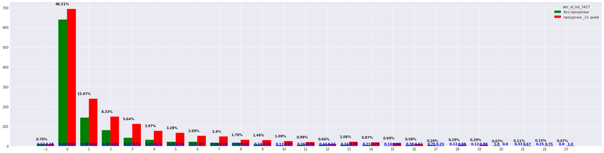

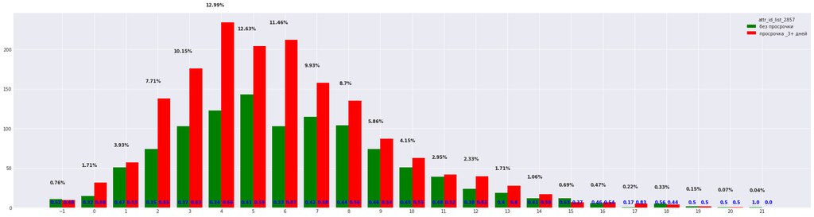

```python
col = main_df[corr_anal]
i = 0

cat_attributes = []

for k in col.columns:
    if k in cat_attr:
        cat_attributes.append(k)

print(cat_attributes)
n = len(cat_attributes)

for row in range(n):

    # текущий атрибут
    attr = cat_attributes[i]

    # датафрейм текущего атрибута всех клиентов
    data = main_df[attr].reset_index(drop=True)

    # значения текущего атрибута всех клиентов
    column_values = data.values
    # список уникальных значений атрибута
    unique_values =  np.unique(column_values)

    # подсчитываем количество клиентов с одинаковыми значениями атрибута
    values_count = []

    for j in range(len(unique_values)):

        values_count.append(list(main_df[attr]).count(unique_values[j]))

    # подсчитываем количество клиентов с одинаковыми значениями атрибута и имеющими или не имеющими задолженность current_status
    val_cnt = np.empty((2, 0)).tolist()

    for j in range(len(unique_values)):
        val_cnt[0].append(list(main_df[main_df[current_status]==0][attr]).count(unique_values[j]))
        val_cnt[1].append(list(main_df[main_df[current_status]==1][attr]).count(unique_values[j]))



    total_loans = len(data)

    #вычисление процентов каждой колонки
    percentage = []
    for j in range(len(unique_values)):
        pct = (values_count[j] / total_loans) * 100
        percentage.append(round(pct,2))
    data['Percentage'] = percentage


    # ширина колонок
    width = 0.4
    fig, ax = plt.subplots(figsize=(32,8))

    # строим график по клиентам без просрочки
    graph = ax.bar(unique_values - width/2,val_cnt[0],width, color='green', label='без просрочки')
    # строим график по клиентам с просрочкой 3+
    graph2 = ax.bar(unique_values + width/2,val_cnt[1],width, color='red', \
                    label=('просрочка '+str(current_status[-2:]))+'+ дней')


    j = 0
    for p in graph:
        width = p.get_width()
        height = p.get_height()
        x, y = p.get_xy()
        if (val_cnt[0][j]+val_cnt[1][j]) == 0:
            plt.text(x+width/2,
                     y+5,
                     str(float("{:.2f}".format(val_cnt[0][j]))),
                     ha='center',
                     weight='bold',
                     c='blue')
        else:
            plt.text(x+width/2,
                     y+5,
                     str(float("{:.2f}".format(val_cnt[0][j]/(val_cnt[0][j]+val_cnt[1][j])))),
                     ha='center',
                     weight='bold',
                     c='blue')
        j+=1

    j = 0
    for p in graph2:
        width = p.get_width()
        height = p.get_height()
        x, y = p.get_xy()
        if (val_cnt[0][j]+val_cnt[1][j]) == 0:
            plt.text(x+width/2,
                 y+5,
                 str(float("{:.2f}".format(val_cnt[1][j]))),
                 ha='center',
                 weight='bold',
                 c='blue')

        else:
            plt.text(x+width/2,
                     y+5,
                     str(float("{:.2f}".format(val_cnt[1][j]/(val_cnt[0][j]+val_cnt[1][j])))),
                     ha='center',
                     weight='bold',
                     c='blue')
        j+=1

    j = 0
    for p in graph2:
        width = p.get_width()
        height = p.get_height()
        x, y = p.get_xy()
        plt.text(x+width/2-0.1,
                 y+height+20,
                 str(float("{:.2f}".format(data.Percentage[j])))+'%',
                 ha='right',
                 weight='bold')
        j+=1

    plt.legend(loc='best',title=attr)
    plt.xticks(unique_values)



    i+=1


plt.show()
```

```python
count_of_values = main_df[current_status].value_counts().sort_index().values
print('Без просрочки '\
      +str(float("{:.2f}".format(count_of_values[0]*100/(count_of_values[0]+count_of_values[1]))))\
      +'% людей')

print('Просрочка '\
      +str(current_status[-2:])+'+ дней '\
      +str(float("{:.2f}".format(count_of_values[1]*100/(count_of_values[0]+count_of_values[1]))))\
      +'% людей')
```

```
Без просрочки 39.63% людей
Просрочка _3+ дней 60.37% людей
```

**При исследовании графиков, можно сделать следующие выводы:**  
1. Будем считать, что изменение количества людей с тем или иным статусом на 20% от первоначального - есть признак аномалия. Тогда примерные пороговые значения для заёмщиков без просрочки: 0.316 (-20%) и 0.474 (+20%); Просрочка 3+ дней: 0.484 и 0.726.

2. График attr_id_list_3427. Наблюдаем линейную зависимость между увеличением значения и увеличением процента просрочек после значений атрибута равным "3". Вывод: этот атрибут следует отобрать для анализа.

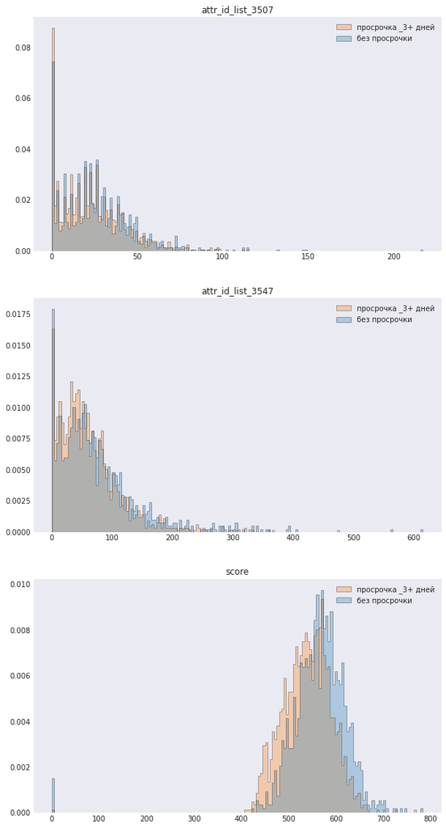

```python
i = 0

num_attributes = []

for k in col.columns:
    if k in num_attr:
        num_attributes.append(k)

n = len(num_attributes)

fig, axes = plt.subplots(n, 1, figsize=(10,20))

for row in range(n):


    plt.style.use('seaborn-white')


    attr = num_attributes[i]

    x1 = main_df[main_df[current_status]==0][attr]
    x2 = main_df[main_df[current_status]==1][attr]


    kwargs = dict(histtype='stepfilled', alpha=0.3,\
                  label=['без просрочки', (('просрочка '+str(current_status[-2:]))+'+ дней')], \
                  density=True, bins=160, ec="k")

    axes[row].hist([x1,x2], **kwargs)

    axes[row].grid()
    axes[row].legend(loc='best')
    axes[row].set_title(attr)

    i+=1


plt.show()
```

```python
expert = ['attr_id_list_3427',  'score']
```

## Эксперт. Итог: 'attr_id_list_3427', 'score'

# ML-методы

```python
# получаем атрибуты
X = main_df[corr_anal]

# получаем статусы
y = main_df[current_status]

# увеличиваем значения на 1, т.к. для тренировки модели X должен быть неотрицательным
for i in corr_anal:
    if -1 in set(X[i]):
        X[i] += 1

# отбираем категариальные атрибуты
X_cat = X[cat_attributes]

# отбираем числовые атрибуты
X_num = X[num_attributes]


X
```

|  | attr_id_list_3427 | attr_id_list_2857 | attr_id_list_3507 | attr_id_list_3547 | score |
| --- | --- | --- | --- | --- | --- |
| 0 | 5.0 | 9.0 | 4.0 | 6.0 | 469 |
| 1 | 3.0 | 9.0 | 23.0 | 190.0 | 579 |
| 2 | 7.0 | 10.0 | 80.0 | 321.0 | 559 |
| 3 | 1.0 | 9.0 | 48.0 | 48.0 | 597 |
| 4 | 7.0 | 4.0 | 0.0 | 20.0 | 455 |
| ... | ... | ... | ... | ... | ... |
| 2743 | 3.0 | 3.0 | 2.0 | 11.0 | 469 |
| 2744 | 3.0 | 6.0 | 3.0 | 4.0 | 501 |
| 2745 | 2.0 | 5.0 | 78.0 | 78.0 | 537 |
| 2746 | 2.0 | 8.0 | 0.0 | 0.0 | 488 |
| 2747 | 2.0 | 12.0 | 28.0 | 187.0 | 652 |

2748 rows × 5 columns

## RFE

```python
from sklearn.feature_selection import RFE
from sklearn.linear_model import LogisticRegression
from sklearn.model_selection import train_test_split
```

```python
# создаём модель
model = LogisticRegression(max_iter=1000)

max_accurancy = 0

for i in range(1,len(X_num)+1):

    # создаём экземпляр модели
    rfe = RFE(model, n_features_to_select=i)

    # разбиваем выборку на тренировочную и тестовую
    X_train, X_test, y_train, y_test = train_test_split(X_num, y, test_size=0.3)

    # обучаем модель
    fit = rfe.fit(X_train, y_train)

    # предсказываем данные
    y_pred = rfe.predict(X_test)

    # вычисляем точность предсказания
    if sum(y_pred == y_test) / len(y_test) > max_accurancy:
        max_accurancy = sum(y_pred == y_test) / len(y_test)
        n = i

# создаём модель с лучшими по статистике параметрами
rfe = RFE(model, n_features_to_select=n)
# обучаем модель
fit = rfe.fit(X_num, y);
```

```python
print("Число признаков: %d" % fit.n_features_)
print("Выбранные признаки: %s" % fit.support_)
print("Ранг признаков: %s" % fit.ranking_)
```

```
Число признаков: 3
Выбранные признаки: [ True  True  True]
Ранг признаков: [1 1 1]
```

```python
features_RFE = []

#отбираем признаки, чей рейтинг равен 1
for i in range(len(fit.feature_names_in_)):
    if fit.ranking_[i]==1:
        features_RFE.append(fit.feature_names_in_[i])

print(features_RFE)
```

```
['attr_id_list_3507', 'attr_id_list_3547', 'score']
```

# Альтернативные методы отбора признаков

## SelectKBest

```python
# https://www.kaggle.com/prashant111/comprehensive-guide-on-feature-selection

from sklearn.feature_selection import SelectKBest, chi2
```

```python
# строим модель. В качестве скорринговой функции используем chi2
selector = SelectKBest(chi2, k="all")

# тренируем модель
selector.fit(X_cat.to_numpy(), y)

# получаем индексы
cols = selector.get_support(indices=True)

# отбираем названия атрибутов по индексу
features_SelectKBest = []

# берём максимальную оценку
max_score = selector.scores_[cols].max()

# отбираем те атрибуты, оценка которых больше или равна половины максимальной оценки среди атрибутов
for i in range(len(selector.scores_)):
    if selector.scores_[i] >= (max_score/2):
        features_SelectKBest.append(X_cat.columns[i])

# выводим отобранные атрибуты
print(features_SelectKBest)
```

```
['attr_id_list_3427']
```

**Судя по всему, алгоритм SelectKBest использует скоринг для оценки важности атрибута, и чем выше оценка, тем первоочерёднее атрибут попадёт в финальную выборку.**

## SelectPercentile

```python
# https://www.kaggle.com/prashant111/comprehensive-guide-on-feature-selection

from sklearn.feature_selection import SelectPercentile
```

```python
# строим модель. В качестве скорринговой функции используем chi2
selector = SelectPercentile(chi2)

# тренируем модель
selector.fit(X_cat.to_numpy(), y)

# получаем индексы
cols = selector.get_support(indices=True)

# отбираем названия атрибутов по индексу
features_SelectPercentile = []

# берём максимальную оценку
max_score = selector.scores_[cols].max()

# отбираем те атрибуты, оценка которых больше или равна половины максимальной оценки среди атрибутов
for i in range(len(selector.scores_)):
    if selector.scores_[i] >= (max_score/2):
        features_SelectPercentile.append(X_cat.columns[i])

# выводим отобранные атрибуты
print(features_SelectPercentile)
```

```
['attr_id_list_3427']
```

**При использовании алгоритма отбора признаков SelectPercentile результаты не поменялись относительно SelectKBest. Вся разница между методами заключается лишь в том, что при SelectKBest мы можем указать конкретное количество желаемых атрибутов, а при SelectPercentile - процент от общего количества атрибутов.**

## Mutual information

```python
# https://www.kaggle.com/prashant111/comprehensive-guide-on-feature-selection

from sklearn.feature_selection import mutual_info_classif
```

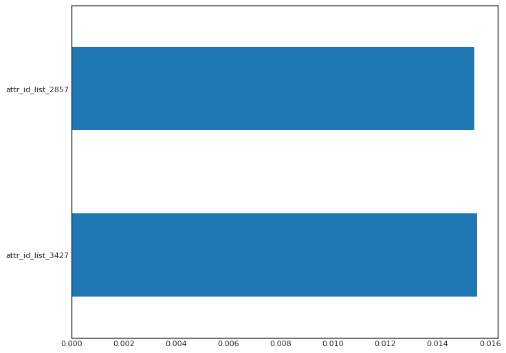

```python
# строим и обучаем классификатор взаимности переменных
importances = mutual_info_classif(X_cat.to_numpy(),y)

# соотносим показатели важности с именами атрибутов
feat_importances = pd.Series(importances, X_cat.columns)

plt.figure(num=None, figsize=(10,8), dpi=80, facecolor='w', edgecolor='k')

# визуализируем степени важности
feat_importances.nlargest(24).plot(kind='barh')
plt.show()
```

```python
# создаём список из атрибутов, чья степень важности больше нуля
list_of_features = list(feat_importances.nlargest(24)[feat_importances>0].index)

'''
# удаляем скоринговые баллы
list_to_remove = []
for i in list_of_features:
    if ('SCORE' in i):
        list_to_remove.append(i)

for i in list_to_remove:
    list_of_features.remove(i)

print('Удаляем следующие атрибуты:')
print(list_to_remove)
'''

print('Остались следующие атрибуты:')
print(list_of_features)
```

```
Остались следующие атрибуты:
['attr_id_list_3427', 'attr_id_list_2857']
```

**При использовании mutual_info_classif с каждым запуском алгоритма остаются разные атрибуты. Вероятно, это происходит потому что при обучении модели с помощью mutual_info_classif в некоторых местах используются псевдослучайные числа.**

## Fisher Score

```python
# https://programtalk.com/python-examples/skfeature.function.similarity_based.fisher_score.fisher_score/

from skfeature.function.similarity_based import fisher_score
```

```python
# оцениваем все атрибуты по степени важности
score = fisher_score.fisher_score(X_cat.to_numpy(), y)
features_fisher_score = []

# отбираем топ-2 атрибутов по важности
for i in range(len(score)):
    if score[i]<=2:
        features_fisher_score.append(X_cat.columns[i])

# выводим отобранные атрибуты
print('Cогласно оценке наиболее важными категориальными переменными оказались:')
print(features_fisher_score)
```

```
Cогласно оценке наиболее важными категориальными переменными оказались:
['attr_id_list_3427', 'attr_id_list_2857']
```

## ANOVA F-value

```python
from sklearn.feature_selection import f_classif
```

```python
selector = SelectKBest(f_classif, k='all')

# тренируем модель
selector.fit(X_cat.to_numpy(), y)

# получаем индексы
cols = selector.get_support(indices=True)

# отбираем названия атрибутов по индексу
features_ANOVA = []

# берём максимальную оценку
max_score = selector.scores_[cols].max()

# отбираем те атрибуты, оценка которых больше или равна четверти максимальной оценки среди атрибутов
for i in range(len(selector.scores_)):
    if selector.scores_[i] >= (max_score/4):
        features_ANOVA.append(X_cat.columns[i])

# выводим отобранные атрибуты
print(features_ANOVA)
```

```
['attr_id_list_3427']
```

## RandomForestClassifier

```python
from sklearn import preprocessing
from sklearn.preprocessing import LabelEncoder
from sklearn.preprocessing import StandardScaler
from sklearn.model_selection import train_test_split
from sklearn import tree
from sklearn.ensemble import RandomForestClassifier
```

```python
# стандартизируем функции, удалив среднее значение и масштабируя до единичной дисперсии
X2 = StandardScaler().fit_transform(X)

#X_train, X_test, y_train, y_test = train_test_split(X2, y, test_size = 0.30, random_state = 0)

# создаём экземпляр классификатора
clf = RandomForestClassifier(n_estimators=100, random_state=0)

# обучаем модель
clf.fit(X2, y)

#clf.fit(X_train, y_train)
#y_pred = clf.predict(X_test)
```

```
RandomForestClassifier(random_state=0)
```

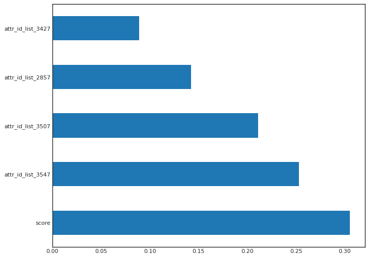

```python
plt.figure(num=None, figsize=(10,8), dpi=80, facecolor='w', edgecolor='k')

feat_importances = pd.Series(clf.feature_importances_, index= X.columns)

feat_importances.nlargest(24).plot(kind='barh')
```

```python
RandomForest_result = list(feat_importances.nlargest(24)[0:2].index)
RandomForest_result
```

```
['score', 'attr_id_list_3547']
```

# Forward Selection

```python
from sklearn.ensemble import RandomForestRegressor
from sklearn.metrics import r2_score

# http://rasbt.github.io/mlxtend/user_guide/feature_selection/SequentialFeatureSelector/
from mlxtend.feature_selection import SequentialFeatureSelector as SFS
```

```python
feature_names = []
best_feature_names_Forward = []
score = 1

# итерационно подбираем лучшее значение k_features
for i in range(0,int(len(X_num.columns))):
    # создаём экземпляр классификатора
    sfs1 = SFS(RandomForestRegressor(),
               k_features=i+1,
               forward=True,
               floating=False,
               verbose=False,
               scoring='r2',
               cv=3,
               n_jobs=-1
                )

    # обучаем модель
    fit = sfs1.fit(X_num, y)

    # список имён отобранных атрибутов
    feature_names_Forward = X_num.columns[list(fit.k_feature_idx_)]

    # значения fit.k_score_ по некой причине получаются все отрицательными, поэтому опытным путём выяснил,
    # что с увеличением количества атрибутов этот показатель ещё активнее уменьшается.
    # Вывод: самое максимальное значение fit.k_score_ соответствует лучшей выборке
    if abs(fit.k_score_) < score:
        score = abs(fit.k_score_)
        best_feature_names_Forward = feature_names_Forward
```

```python
list(best_feature_names_Forward)
```

```
['attr_id_list_3507']
```

**Если подбирать количество требуемых атрибутов, то даже при n_jobs=-1 алгоритм расходует много памяти**

# Backward Elimination

```python
feature_names = []
best_feature_names_Backward = []
score = 1

# итерационно подбираем лучшее значение k_features
for i in range(0,int(len(X_num.columns))):
    # создаём экземпляр классификатора
    sfs1 = SFS(RandomForestRegressor(),
               k_features=i+1,
               forward=False,
               floating=False,
               verbose=False,
               scoring='r2',
               cv=3,
               n_jobs=-1
                )

    # обучаем модель
    fit = sfs1.fit(X_num, y)

    # список имён отобранных атрибутов
    feature_names_Backward = X_num.columns[list(fit.k_feature_idx_)]

    # значения fit.k_score_ по некой причине получаются все отрицательными, поэтому опытным путём выяснил,
    # что с увеличением количества атрибутов этот показатель ещё активнее уменьшается.
    # Вывод: самое максимальное значение fit.k_score_ соответствует лучшей выборке
    if abs(fit.k_score_) < score:
        score = abs(fit.k_score_)
        best_feature_names_Backward = feature_names_Backward
```

```python
list(best_feature_names_Backward)
```

```
['attr_id_list_3507', 'attr_id_list_3547', 'score']
```

**Выполнение Backward Elimination ещё более затратно по памяти**

# Подсчёт статистики

```python
result_df = pd.DataFrame(index=corr_anal, columns=['count'])
result_df.fillna(int(0), inplace=True)


for i in features_RFE:
    result_df['count'][i] += 1
for i in features_fisher_score:
    result_df['count'][i] += 1
for i in corr_anal:
    result_df['count'][i] += 1
for i in expert:
    result_df['count'][i] += 1
for i in features_SelectKBest:
    result_df['count'][i] += 1

'''
for i in best_feature_names_Forward:
    result_df['count'][i] += 1
for i in best_feature_names_Backward:
    result_df['count'][i] += 1
for i in RandomForest_result:
    result_df['count'][i] += 1
for i in features_ANOVA:
    result_df['count'][i] += 1



'''
result_df
```

|  | count |
| --- | --- |
| attr_id_list_3427 | 4 |
| attr_id_list_2857 | 2 |
| attr_id_list_3507 | 2 |
| attr_id_list_3547 | 2 |
| score | 3 |

```python
print('Отобранные атрибуты:')
result_df[(result_df['count']==result_df['count'].max())|(result_df['count']==result_df['count'].max()-1)]
```

```
Отобранные атрибуты:
```

|  | count |
| --- | --- |
| attr_id_list_3427 | 4 |
| score | 3 |

## Корреляционный анализ. Итог: 'attr_id_list_3427', 'attr_id_list_2857', 'attr_id_list_3507', 'attr_id_list_3547', 'score'

## Эксперт. Итог: 'attr_id_list_3427', 'score'

## Машина. Итог: 'attr_id_list_3427', 'attr_id_list_2857', 'attr_id_list_3507', 'attr_id_list_3547', 'score'

# Общий итог: 'attr_id_list_3427', 'score'